# Reproducible Research: Peer Assessment 1

## Loading and preprocessing the data

```r
  library(tidyverse)
  activity <- read_csv("activity.csv")
  head(activity)
```

```
## # A tibble: 6 × 3
##   steps date       interval
##   <dbl> <date>        <dbl>
## 1    NA 2012-10-01        0
## 2    NA 2012-10-01        5
## 3    NA 2012-10-01       10
## 4    NA 2012-10-01       15
## 5    NA 2012-10-01       20
## 6    NA 2012-10-01       25
```

## What is mean total number of steps taken per day?

Calculate total number of steps per day

```r
steps_per_day <- with(activity, aggregate(steps, list(date), FUN = sum, na.rm = TRUE))
head(steps_per_day)
```

```
##      Group.1     x
## 1 2012-10-01     0
## 2 2012-10-02   126
## 3 2012-10-03 11352
## 4 2012-10-04 12116
## 5 2012-10-05 13294
## 6 2012-10-06 15420
```

Show a histogram

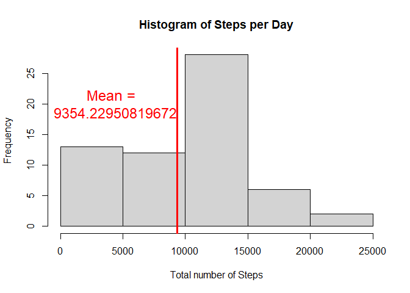

```r
hist(x = steps_per_day$x, main = "Histogram of Steps per Day", xlab = "Total number of Steps", ylab = "Frequency")

abline(v = mean(steps_per_day$x),                       # Add line for mean
       col = "red",
       lwd = 3)
text(x = mean(steps_per_day$x) / 2.2,                   # Add text for mean
     y = 20 ,
     paste("Mean = \n", mean(steps_per_day$x)),
     col = "red",
     cex = 1.5)
```

### Mean and median number of steps taken each day

Mean (excluding missing values)

```r
mean(steps_per_day$x, na.rm = TRUE)
```

```
## [1] 9354.23
```

Median (excluding missing values)

```r
median(steps_per_day$x, na.rm = TRUE)
```

```
## [1] 10395
```

### Which 5-minute interval, on average across all the days in the dataset, contains the maximum number of steps?

```r
activity%>% group_by(interval) %>%
    summarize(meanByInterval = mean(steps, na.rm = TRUE)) %>%
    filter(meanByInterval == max(meanByInterval))
```

```
## # A tibble: 1 × 2
##   interval meanByInterval
##      <dbl>          <dbl>
## 1      835           206.
```

## What is the average daily activity pattern?

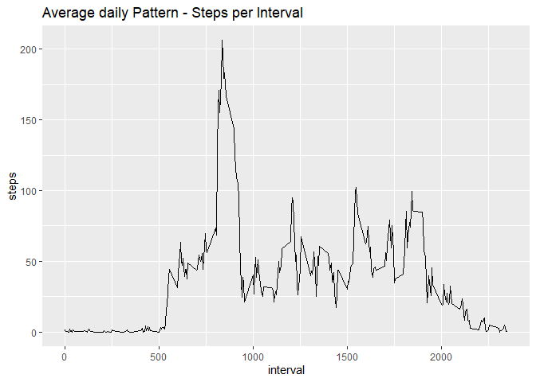

```r
  stepsPerIntervalAvg <- aggregate(steps ~ interval, data = activity, FUN = mean, na.action = na.omit)
colnames(stepsPerIntervalAvg) <- c("interval", "steps")
ggplot(stepsPerIntervalAvg) +
  geom_line(aes(interval,steps)) +
  ggtitle("Average daily Pattern - Steps per Interval")
```

One can clearly see that the Person sleeps in the morning, does the most activity on 09:00 AM, than has mixed activity until 19:00 PM and then the activity decreases steadily.

## Imputing missing values

Let’s see, which days are affected by “NA”s

```r
steps_per_day <- with(activity, aggregate(steps, list(date), FUN = sum, na.rm = FALSE))
head(steps_per_day)
```

```
##      Group.1     x
## 1 2012-10-01    NA
## 2 2012-10-02   126
## 3 2012-10-03 11352
## 4 2012-10-04 12116
## 5 2012-10-05 13294
## 6 2012-10-06 15420
```

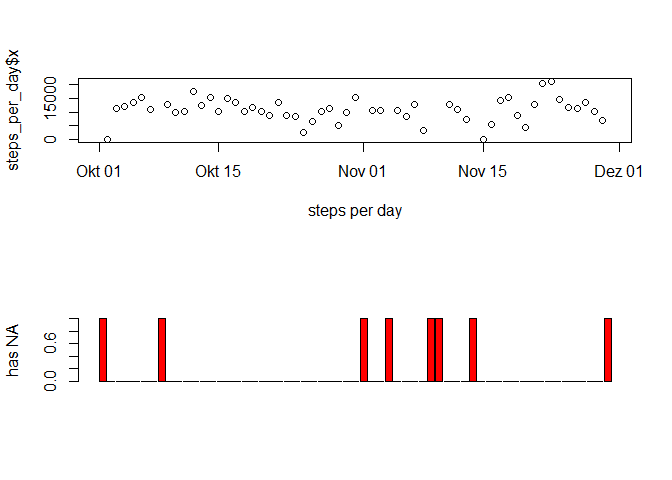

```r
par(mfrow=c(2,1))    # set the par-function for subplots
plot(steps_per_day$x ~ steps_per_day$Group.1, xlab = "steps per day")
barplot(is.na(steps_per_day$x), col = "red", ylab = "has NA")
```

So how many NA have we got?

```r
sum(is.na(activity$steps) == TRUE)
```

```
## [1] 2304
```

okay, enough to take care about.

### actual imputation

strategy: fill the void with the mean value in that 5-Minute-Timeframe

```r
activity_imp <- activity # create new dataset
for (i in stepsPerIntervalAvg$interval) {
    activity_imp[activity_imp$interval == i & is.na(activity_imp$steps), ]$steps <-
        stepsPerIntervalAvg$steps[stepsPerIntervalAvg$interval == i]
}
head(activity_imp) # no NAs
```

```
## # A tibble: 6 × 3
##    steps date       interval
##    <dbl> <date>        <dbl>
## 1 1.72   2012-10-01        0
## 2 0.340  2012-10-01        5
## 3 0.132  2012-10-01       10
## 4 0.151  2012-10-01       15
## 5 0.0755 2012-10-01       20
## 6 2.09   2012-10-01       25
```

### plot imputed data

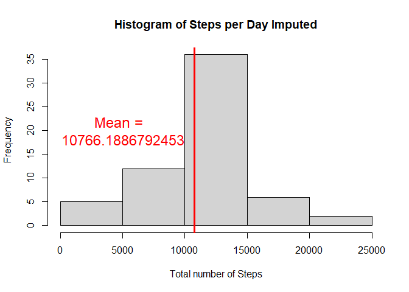

```r
steps_per_day_imp <- with(activity_imp, aggregate(steps, list(date), FUN = sum, na.rm = TRUE))
hist(x = steps_per_day_imp$x, main = "Histogram of Steps per Day Imputed", xlab = "Total number of Steps", ylab = "Frequency")

abline(v = mean(steps_per_day_imp$x),                       # Add line for mean
       col = "red",
       lwd = 3)
text(x = mean(steps_per_day_imp$x) / 2.2,                   # Add text for mean
     y = 20 ,
     paste("Mean = \n", mean(steps_per_day_imp$x)),
     col = "red",
     cex = 1.5)
```

Mean

```r
mean(steps_per_day_imp$x)
```

```
## [1] 10766.19
```

Median

```r
median(steps_per_day_imp$x)
```

```
## [1] 10766.19
```

## Are there differences in activity patterns between weekdays and weekends?

[figure not shown]

```r
activity %>% add_column(weekend = as.integer(format(as.Date(activity$date),"%w"))>=4) -> activity_weekdays

stepsPerIntervalAvg_weekdays <- aggregate(steps ~ interval+ weekend, data = activity_weekdays, FUN = mean, na.action = na.omit)

ggplot(stepsPerIntervalAvg_weekdays) +
  geom_line(aes(interval,steps, col = weekend)) +
  ggtitle("Average daily Pattern - Steps per Interval")
```